# Linguistics 200

Day 11: Building a Vowel System

Dr. Andrew M. Byrd

# Quiz

# Review: IPA

## Decode the Word: Reading IPA

Using the American English IPA sheet, identify the following English words

1. /kæt/
2. /haʊs/
3. /skul/
4. /θɪŋk/
5. /brɔt/
6. /ˈkʌmfərt/
7. /ˈɛlɪfənt/
8. /ˈjunɪkɔrn/

# Vowels

## What Makes a Consonant

Consonants involve at least one real point of obstruction — a full or partial closure somewhere in the vocal tract.

## What Makes a Vowel

Vowels involve no closure at all — an open vocal tract, shaped by the tongue and lips into different resonating cavities.

## Real-Time MRI of Spoken Language

[video not shown]

- How are Vowels Made?

## The Classic IPA “Trapezoid”

## Oral Cavity > “Trapezoid”

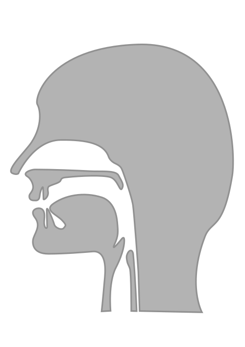

- Front of the mouth (lips/teeth) is on the **left**; back of the throat (pharynx) is on the **right**
- The tongue body rises toward the palate for **high** vowels, drops toward the jaw for **low** ones

## Moving the Tongue Around: Height & Frontness

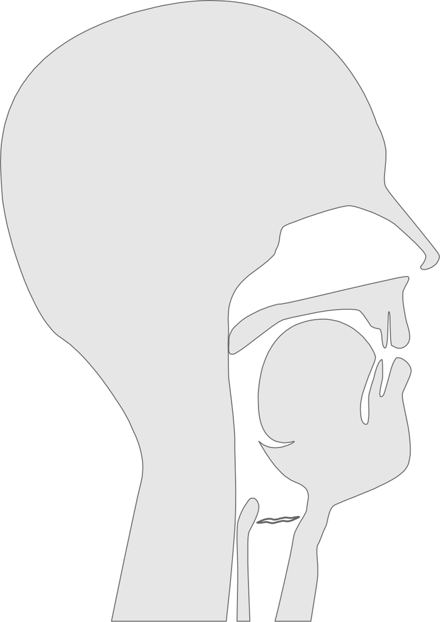

[i] — high, front

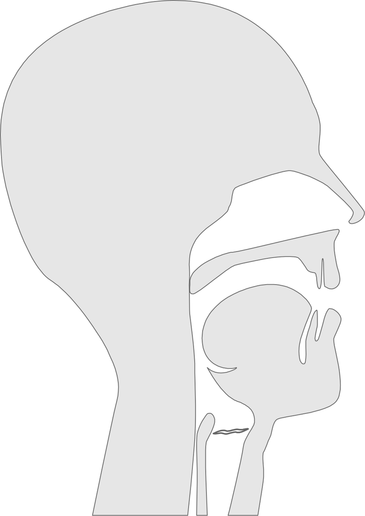

[a] — low

## Height

The vertical position of the tongue body in the mouth.

- **High**: tongue raised close to the roof of the mouth — [i] as in *beet*
- **Mid**: in between — [ɛ] as in *bet*
- **Low**: tongue low, jaw dropped — [æ] as in *bat*

## Frontness

The horizontal position of the tongue body.

- **Front**: tongue bunched toward the front — [i] as in *beet*
- **Central**: neither — [ʌ] as in *but*
- **Back**: tongue pulled toward the back — [u] as in *boot*

## Feeling Your Tongue Move

beet

bit

bait

bet

bat

## Feeling Your Tongue Move

boot

put

boat

bought

bot

## Feeling Your Tongue Move

beet

boot

## Feeling Your Tongue Move

bait

boat

## Do you notice anything else changing besides tongue placement?

beet ~ boot

bait ~ boat

## Roundedness

- **Rounded**: lips protruded/rounded — [u] as in *boot*
- **Unrounded**: lips spread or neutral — [i] as in *beet*

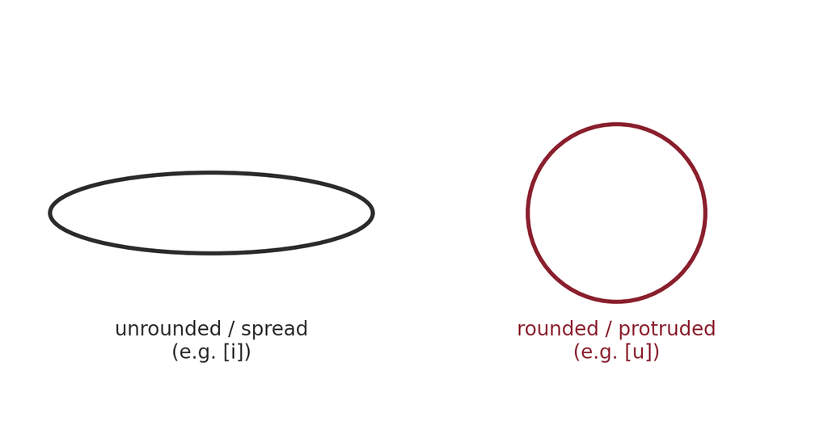

## Tenseness

- **Tense**: produced with more muscular tension, often slightly longer — [i] as in *beet*
- **Lax**: more relaxed, often shorter — [ɪ] as in *bit*
- Tenseness pairs vowels at a similar height: i/ɪ, e/ɛ, u/ʊ, o/ɔ

## Consonant Features

1. Place
2. Manner
3. Voicing

## Vowel Features

1. Height
2. Frontness
3. Roundedness
4. Tenseness

## The Full IPA Vowel Space

## The English IPA Vowel Space

## Reading the IPA Chart

- tense vs. lax
- rounded vs. unrounded

# Identifying Vowel Features

## Activity

- Referring to your IPA chart, identify:
  - the features of each symbol:
    1. /ɪ/
    2. /ʌ/
    3. /y/
  - the symbol matching each description:
    4. High, back, rounded, tense
    5. Low, front, unrounded
    6. Mid, front, rounded, tense

# How Other Languages Differ

## How Normal is the English Vowel System?

## Difference 1: Fewer Vowels

- Many languages get by with far fewer vowel qualities
- **Spanish**, **Japanese**: five vowels — i, e, a, o, u/ɯ
- **Classical Arabic**: three vowel qualities — i, a, u (each short or long)

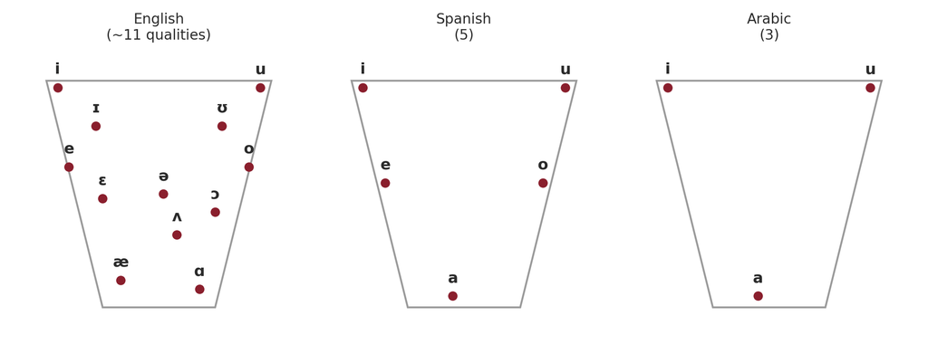

## Vowel Space Distributions

- Do you notice anything interesting about the distribution of vowels in Spanish & Arabic?

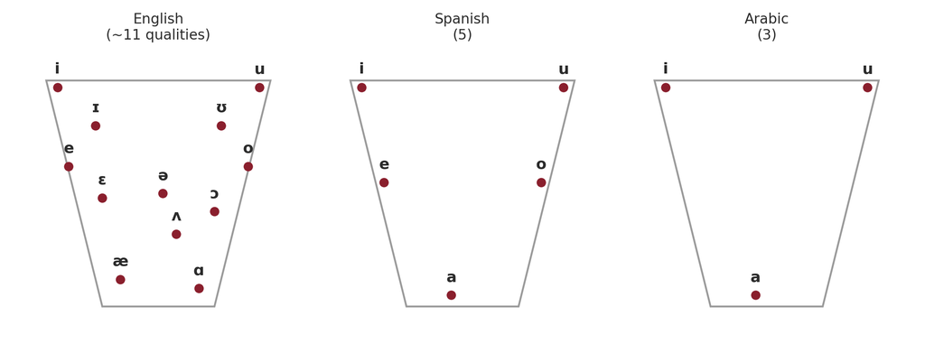

## Vowel Space Distributions

- How about Turkish?

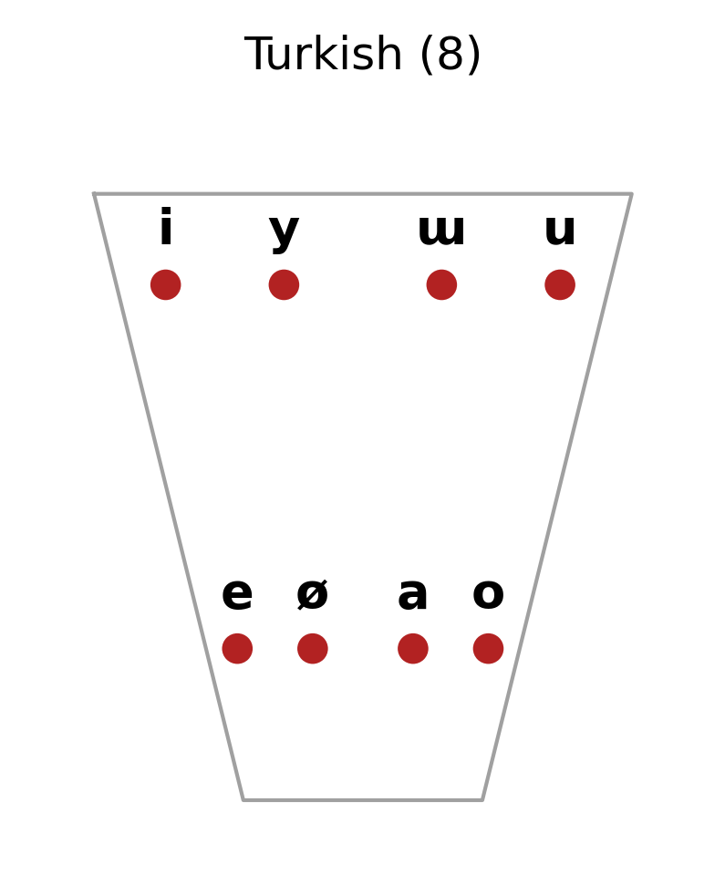

## Vowel Space Distributions

- How about Italian?

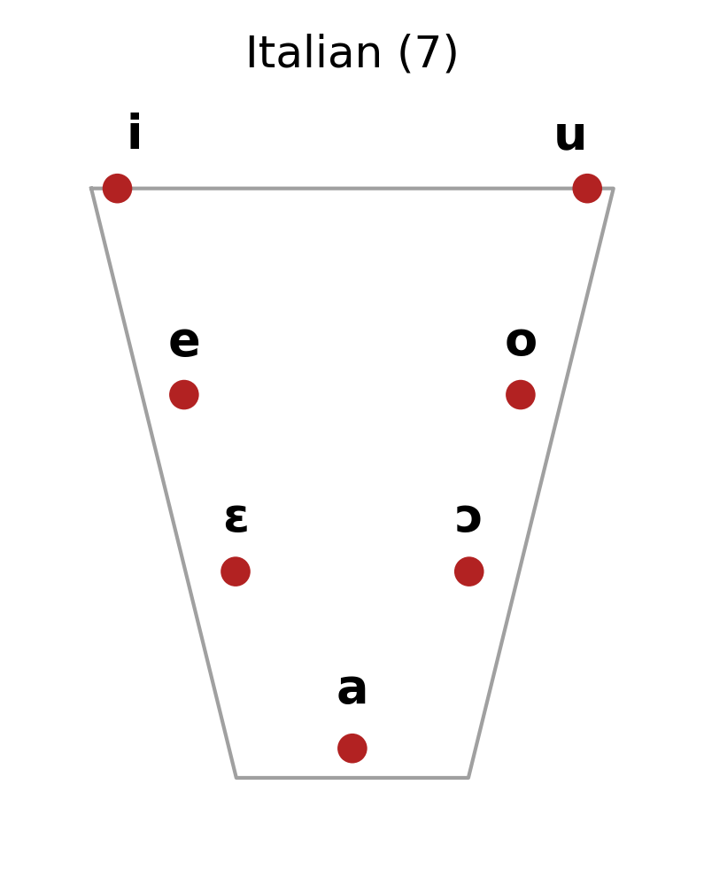

## Elevator Analogy

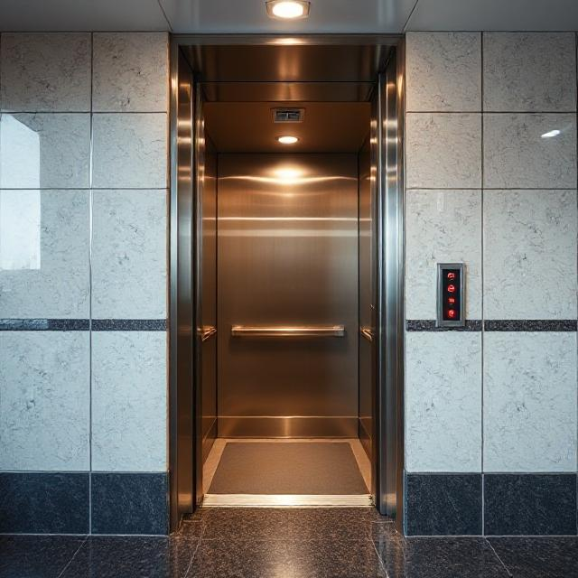

## Difference 2: Nasality

- In English, vowels are nasalized only automatically, in front of a nasal consonant (*bat* vs. *ban*) — it’s not contrastive

## Difference 2: Nasality

- In **French**, nasality is its own phoneme: *bon* [bɔ̃] “good” vs. *beau* [bo] “beautiful”

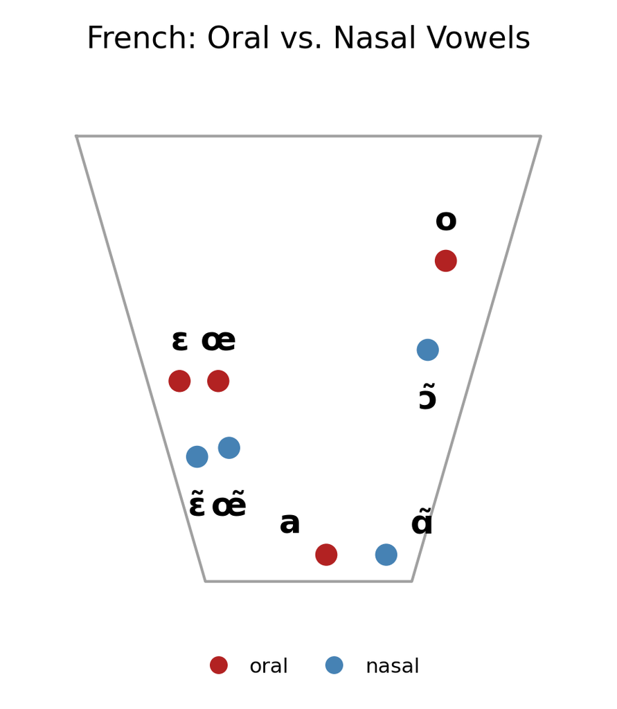

## Difference 2: Nasality

- Also contrastive in **Portuguese**, and in many languages of West Africa and Amazonia

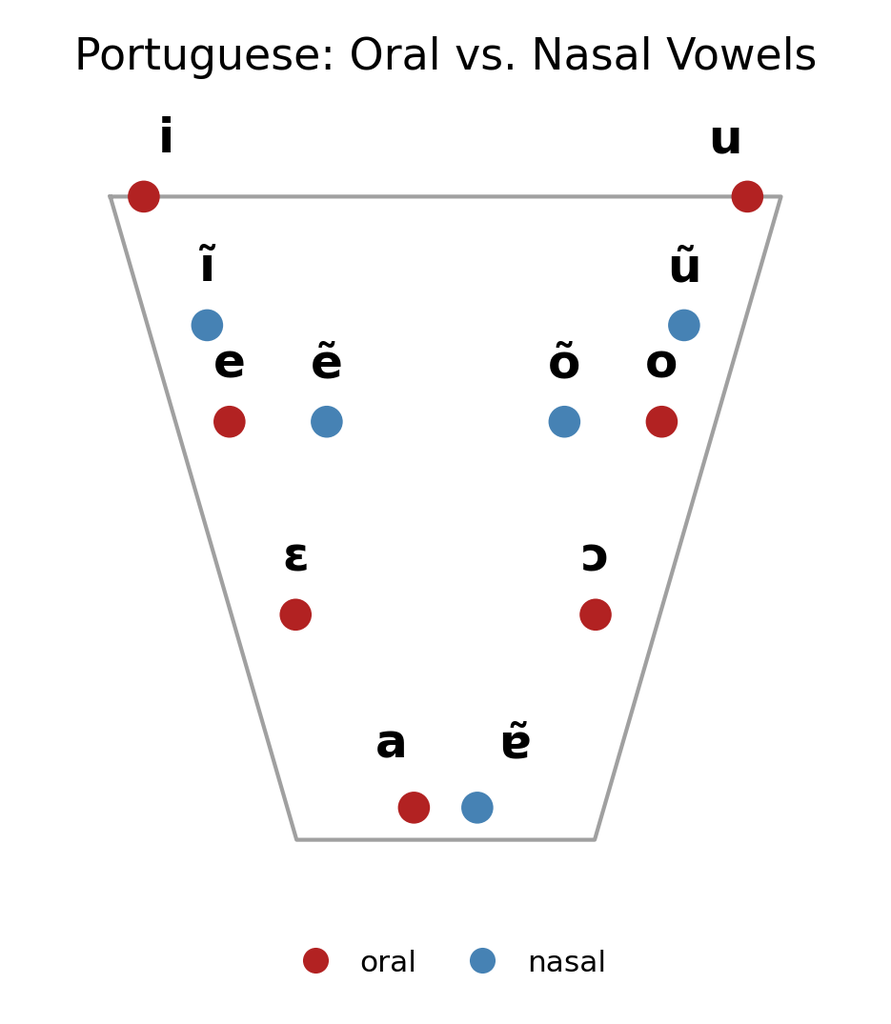

## Difference 3: Front Rounded & Back Unrounded Vowels

- In English, front vowels = **unrounded**; back vowels are almost entirely **round**

## Difference 3: Front Rounded & Back Unrounded Vowels

- **Front rounded**: French [y] *tu*, [ø] *peu*, [œ] *sœur*; German ü, ö

[figure not shown]

## Difference 3: Front Rounded & Back Unrounded Vowels

- **Back unrounded**: Turkish ı [ɯ]; Japanese u [ɯ]; Korean 으 [ɯ]

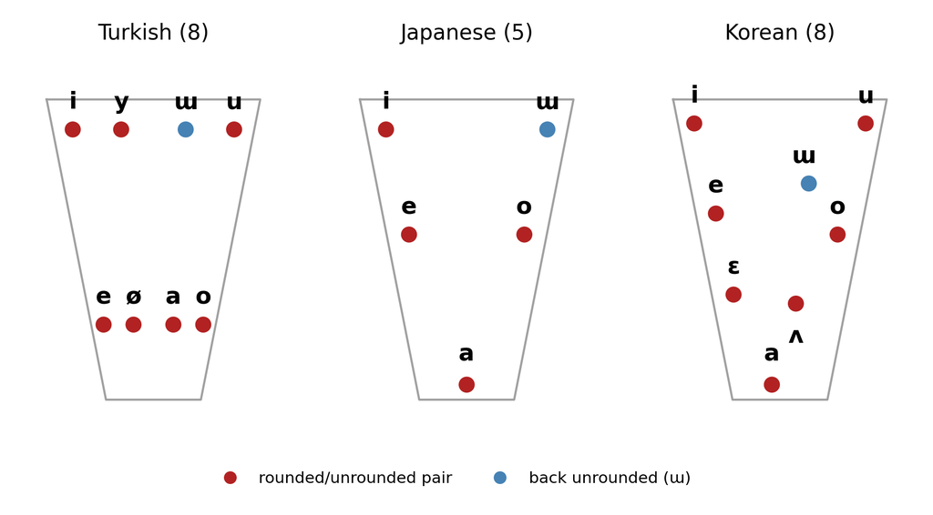

## Difference 4: Vowel Length

- Some languages treat length as its own contrast, not just a byproduct of quality
- Short vs. long vowel = a completely different word

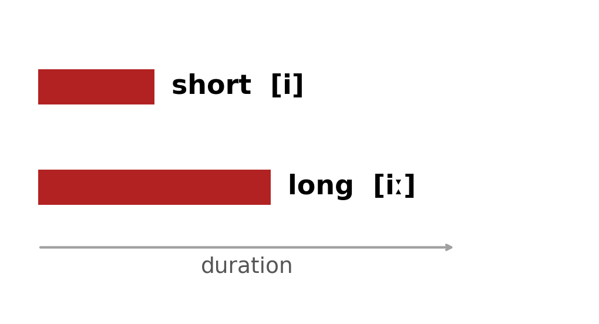

## Difference 4: Vowel Length

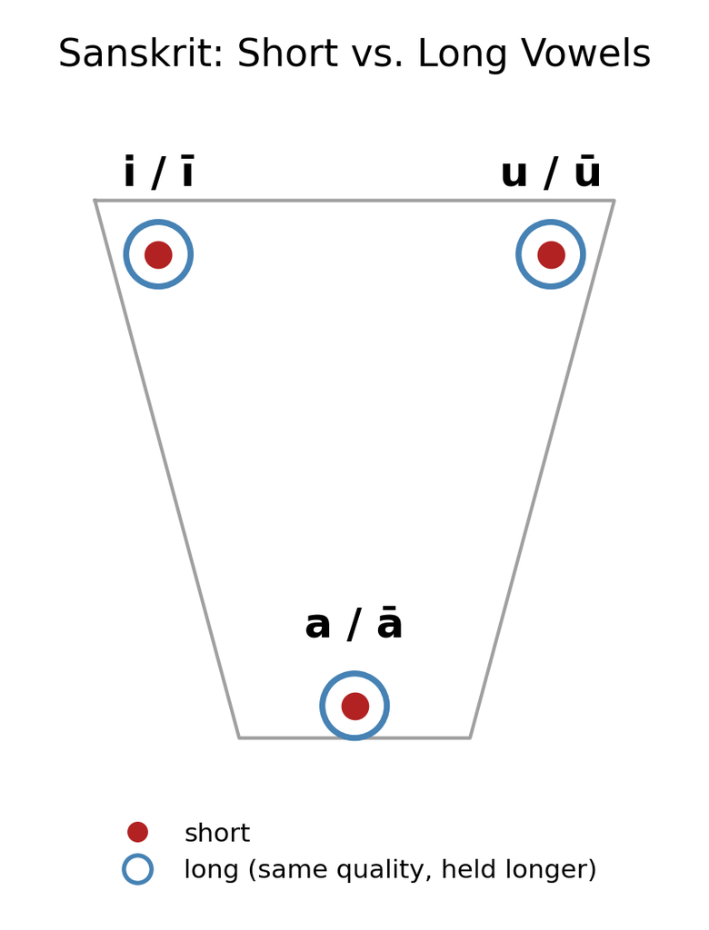

## Difference 4: Vowel Length

- Sanskrit even has a **syllabic r** — /ṛ/ and /ṝ/ — a vowel made from a consonant!
- Vowels can also be coded as “always long”: /e/, /o/, /ai/, /au/

## Back to Your Language

Which of these differences might show up in *your* invented language’s vowel system?

- Fewer vowels than English?
  - I *strongly* recommend this!
- Contrastive nasality?
- Front rounded vowels?
- Back unrounded vowels?
- Vowel length?